# Notebook

**Research Question:** "What treatments improve PSSD (Post-SSRI Sexual Dysfunction) once people have it?"

## Data Exploration

Data covers: 2026-03-12 to 2026-04-11 (1 month). Source: r/PSSD subreddit.

| Metric | Count |
| --- | --- |
| Total users | 500 |
| Total posts | 2,532 |
| Treatment reports | 902 |
| Unique reporters | 220 |
| Unique drugs mentioned | 245 |

**PSSD (Post-SSRI Sexual Dysfunction)** is a condition where sexual side effects from serotonergic antidepressants persist after discontinuation. The r/PSSD community discusses causative drugs (which caused their condition) and recovery treatments (which they try to improve symptoms). This analysis focuses exclusively on recovery treatments.

## Filtering and Methodology

**Causative drugs excluded:** SSRIs (sertraline, fluoxetine, paroxetine, escitalopram, citalopram, vortioxetine, lexapro/escitalopram, prozac/fluoxetine), SNRIs (duloxetine, venlafaxine), finasteride, atomoxetine, brintellix, olanzapine, and antipsychotics. These drugs are discussed in r/PSSD as the *cause* of the condition, not as treatments. Their overwhelmingly negative sentiment (93% negative on average) reflects causation context, not treatment response.

**Generic terms excluded:** "antidepressant", "supplements", "medication", "treatment", "therapy", "drug" -- these are categories, not actionable treatments.

**Duplicates merged:** dextromethorphan/dxm, weed/cannabis/marijuana, cyproheptadine/ciproheptadine, 75mg/bupropion (75mg references bupropion dosing).

**Mechanism groupings:** Treatments are assigned to 10 mechanistic categories (Dopaminergic, Serotonin Antagonists, Antihistamines/Mast Cell, Psychedelics, PDE5 Inhibitors, Hormonal, Opioid Modulators, Diet/Lifestyle, Supplements, Other Pharmaceuticals) based on primary pharmacological action. Some drugs could fit multiple categories (e.g., cyproheptadine is both a serotonin antagonist and antihistamine); we assigned based on the mechanism most relevant to PSSD recovery literature.

## Baseline: What Does the Recovery Landscape Look Like?

Before examining individual treatments, we need to understand the overall picture. What proportion of recovery attempts result in positive reports? This baseline sets expectations for what "good" looks like in this community.

Recovery Treatment Baseline

| **Total recovery treatment trials:** | 417 |
| --- | --- |
| **Positive outcomes:** | 161 (38.6%) |
| **Negative outcomes:** | 187 (44.8%) |
| **Mixed/Neutral outcomes:** | 69 (16.5%) |
| **Baseline positive rate:** | 38.6% (95% Wilson CI: 34.1% to 43.4%) |
| **Significantly different from 50%?** | Yes (p=0.0000) |

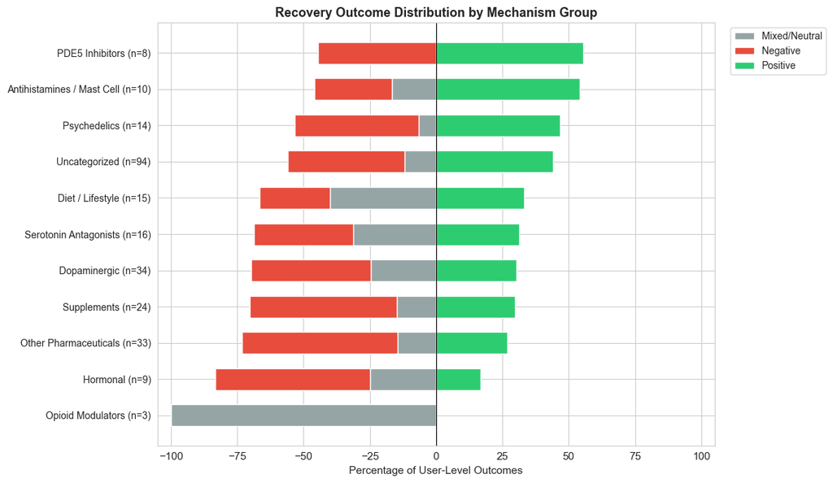

## Core Analysis: Which Individual Treatments Show Promise?

With the mechanism-level landscape established, we now examine individual treatments with at least 3 user reports. Each treatment is tested against the community baseline positive rate using a binomial test, with Wilson score confidence intervals to account for small samples.

All Recovery Treatments (n >= 3 users), Ranked by Positive Rate

|  | Treatment | Mechanism | Users | Positive | Pos Rate | Wilson 95% CI | p-value | NNT |
| --- | --- | --- | --- | --- | --- | --- | --- | --- |
| 0 | tadalafil | PDE5 Inhibitors | 5 | 4 | 80% | 38% to 96% | 0.0768 | 2.4 |
| 1 | ketogenic diet | Diet / Lifestyle | 5 | 4 | 80% | 38% to 96% | 0.0768 | 2.4 |
| 2 | microdosing | Psychedelics | 5 | 4 | 80% | 38% to 96% | 0.0768 | 2.4 |
| 3 | amphetamine | Dopaminergic | 3 | 2 | 67% | 21% to 94% | 0.3321 | 3.6 |
| 4 | ketotifen | Antihistamines / Mast Cell | 3 | 2 | 67% | 21% to 94% | 0.3321 | 3.6 |
| 5 | lsd | Psychedelics | 3 | 2 | 67% | 21% to 94% | 0.3321 | 3.6 |
| 6 | cetirizine | Antihistamines / Mast Cell | 3 | 2 | 67% | 21% to 94% | 0.3321 | 3.6 |
| 7 | antihistamine | Antihistamines / Mast Cell | 6 | 4 | 67% | 30% to 90% | 0.1605 | 3.6 |
| 8 | loratadine | Antihistamines / Mast Cell | 5 | 3 | 60% | 23% to 88% | 0.2937 | 4.7 |
| 9 | pramipexole | Dopaminergic | 5 | 3 | 60% | 23% to 88% | 0.2937 | 4.7 |
| 10 | omega-3 fatty acids | Supplements | 4 | 2 | 50% | 15% to 85% | 0.5006 | 8.8 |
| 11 | trazodone | Other Pharmaceuticals | 4 | 2 | 50% | 15% to 85% | 0.5006 | 8.8 |
| 12 | magnesium | Supplements | 4 | 2 | 50% | 15% to 85% | 0.5006 | 8.8 |
| 13 | vitamin c | Supplements | 5 | 2 | 40% | 12% to 77% | 0.6386 | 71.9 |
| 14 | cyproheptadine | Serotonin Antagonists | 8 | 3 | 38% | 14% to 69% | 0.6549 | n/a |
| 15 | testosterone | Hormonal | 3 | 1 | 33% | 6% to 79% | 0.7686 | n/a |
| 16 | quercetin | Antihistamines / Mast Cell | 3 | 1 | 33% | 6% to 79% | 0.7686 | n/a |
| 17 | gabapentin | Other Pharmaceuticals | 9 | 3 | 33% | 12% to 65% | 0.7411 | n/a |
| 18 | weed | Other Pharmaceuticals | 9 | 3 | 33% | 12% to 65% | 0.7411 | n/a |
| 19 | cabergoline | Dopaminergic | 9 | 3 | 33% | 12% to 65% | 0.7411 | n/a |
| 20 | tre | Diet / Lifestyle | 3 | 1 | 33% | 6% to 79% | 0.7686 | n/a |
| 21 | pt-141 | Other Pharmaceuticals | 3 | 1 | 33% | 6% to 79% | 0.7686 | n/a |
| 22 | stimulants | Dopaminergic | 3 | 1 | 33% | 6% to 79% | 0.7686 | n/a |
| 23 | liposomal quercetin | Antihistamines / Mast Cell | 4 | 1 | 25% | 5% to 70% | 0.8580 | n/a |
| 24 | buspirone | Serotonin Antagonists | 8 | 2 | 25% | 7% to 59% | 0.8783 | n/a |
| 25 | methylphenidate | Dopaminergic | 4 | 1 | 25% | 5% to 70% | 0.8580 | n/a |
| 26 | sildenafil | PDE5 Inhibitors | 4 | 1 | 25% | 5% to 70% | 0.8580 | n/a |
| 27 | dopaminergic drugs | Dopaminergic | 4 | 1 | 25% | 5% to 70% | 0.8580 | n/a |
| 28 | testosterone replacement therapy | Hormonal | 4 | 1 | 25% | 5% to 70% | 0.8580 | n/a |
| 29 | alcohol | Other Pharmaceuticals | 4 | 1 | 25% | 5% to 70% | 0.8580 | n/a |

**How to read this table:** Each row is a treatment tried by at least 3 distinct users. The positive rate is the fraction of users whose average sentiment was positive. The Wilson 95% CI accounts for small sample sizes -- wide intervals mean the true positive rate could be much higher or lower. The p-value tests whether the positive rate exceeds the community baseline. NNT (Number Needed to Treat) estimates how many people would need to try the treatment for one additional person to report benefit beyond baseline.

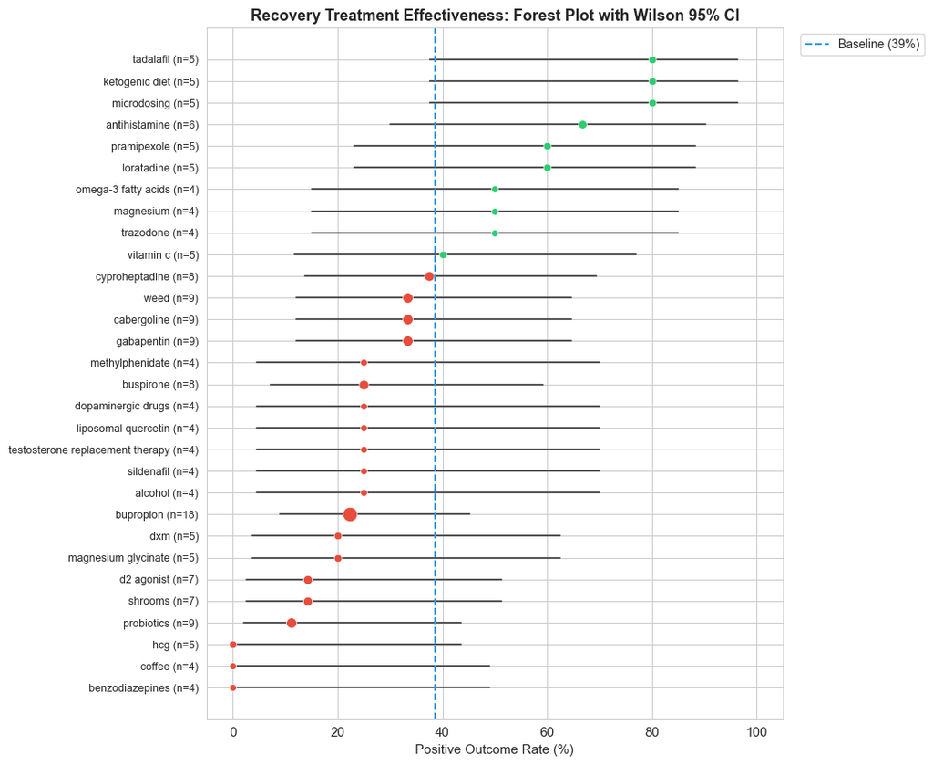

**What this means:** Each dot represents a treatment's positive rate, with horizontal lines showing the 95% confidence interval. Dot size reflects sample size. The dashed blue line marks the community baseline. Treatments to the right of the baseline are performing better than average. Notice how treatments with very small samples (n=3-5) have extremely wide confidence intervals -- their position on this chart is suggestive but unreliable. The most credible signals come from treatments with both high positive rates AND reasonable sample sizes (narrower intervals).

## Mechanism Deep Dive: Grouping Treatments by How They Work

Individual drug comparisons are noisy with these sample sizes. Grouping by mechanism aggregates evidence and reveals whether an entire pharmacological strategy shows promise -- which is more actionable than knowing a single drug's positive rate.

Kruskal-Wallis Test: Do Mechanism Groups Differ?

**H statistic:** 10.05 | **p-value:** 0.3465 | **eta-squared (effect size):** 0.003

**No significant difference** between mechanism groups at alpha=0.05.

**Plain language:** We cannot confirm that mechanism groups differ -- the variation between groups may be due to chance given our sample sizes.

Mechanism Group Performance vs Community Baseline

|  | Mechanism | N Users | N Trials | Pos Rate | Wilson CI | p vs baseline | Mean Score |
| --- | --- | --- | --- | --- | --- | --- | --- |
| 7 | Uncategorized | 94 | 202 | 44% | 37% to 51% | 0.1125 | 0.04 |
| 9 | Antihistamines / Mast Cell | 10 | 24 | 54% | 35% to 72% | 0.1421 | 0.28 |
| 1 | Hormonal | 9 | 12 | 17% | 5% to 45% | 0.1458 | -0.35 |
| 2 | Other Pharmaceuticals | 33 | 41 | 27% | 16% to 42% | 0.1486 | -0.26 |
| 4 | Dopaminergic | 34 | 53 | 30% | 20% to 44% | 0.2589 | -0.08 |
| 0 | Opioid Modulators | 3 | 3 | 0% | 0% to 56% | 0.2889 | 0.50 |
| 10 | PDE5 Inhibitors | 8 | 9 | 56% | 27% to 81% | 0.3207 | 0.09 |
| 3 | Supplements | 24 | 27 | 30% | 16% to 48% | 0.4305 | -0.19 |
| 8 | Psychedelics | 14 | 15 | 47% | 25% to 70% | 0.5988 | 0.01 |
| 5 | Serotonin Antagonists | 16 | 16 | 31% | 14% to 56% | 0.6171 | 0.08 |
| 6 | Diet / Lifestyle | 15 | 15 | 33% | 15% to 58% | 0.7947 | 0.23 |

**What this means:** This table tests whether each mechanism group performs differently from the community baseline. Groups with low p-values have statistically distinguishable performance. Note that groups with very few trials have wide confidence intervals and limited statistical power.

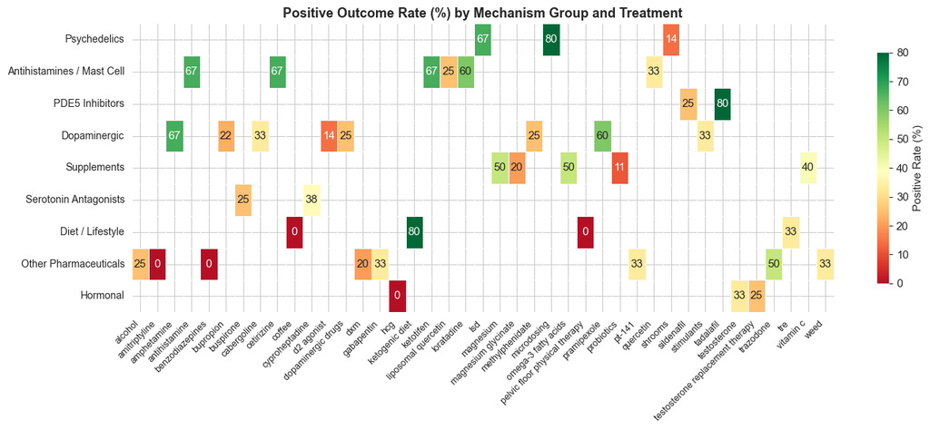

## Bupropion: The Most-Reported Recovery Treatment

Bupropion Recovery Profile

| **Users reporting:** | 18 |
| --- | --- |
| **Positive:** | 4 (22%) |
| **Negative:** | 8 (44%) |
| **Mixed/Neutral:** | 6 (33%) |
| **Wilson 95% CI:** | 9% to 45% |
| **vs Baseline (39%):** | p=0.9577 (binomial, one-sided) |
| **Cohen h:** | -0.359 (small effect) |
| **NNT:** | n/a (number needed to treat for 1 additional positive outcome vs baseline) |

**Sensitivity check:** Dropping the most extreme positive and negative users, bupropion positive rate is 19% (n=16). The finding is robust.

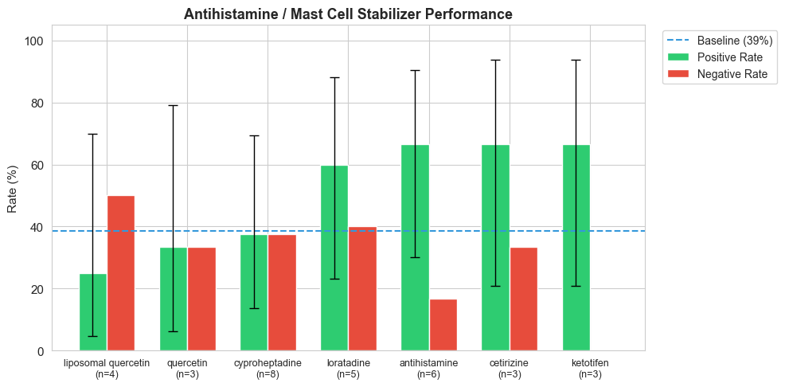

**Antihistamines vs all other recovery treatments (Fisher exact):** OR=1.66, p=0.1180  
**Plain language:** The antihistamine advantage does not reach statistical significance, though the trend is positive. Wide confidence intervals due to small samples mean we cannot rule out a meaningful benefit.

Dopaminergic agents represent the largest mechanism group with the most user reports. Bupropion dominates, but cabergoline and pramipexole also appear. How do they compare within the class?

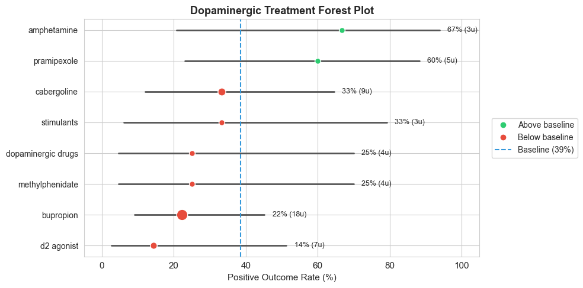

## Emerging Signals: Diet, Lifestyle, and Psychedelics

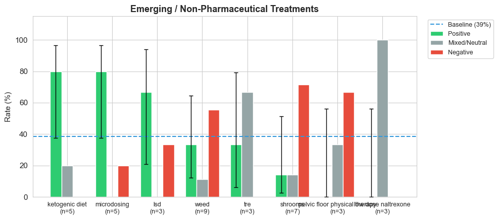

**ketogenic diet:** 80% positive (n=5), p=0.0768 vs baseline. Marginally significant at alpha=0.10. NNT=2.4

**microdosing:** 80% positive (n=5), p=0.0768 vs baseline. Marginally significant at alpha=0.10. NNT=2.4

## Counterintuitive Findings Worth Investigating

1. Cyproheptadine: The Polarizing Serotonin Antagonist

Cyproheptadine -- a 5-HT2A/2C antagonist and H1 antihistamine -- splits the community down the middle: 3/8 users report positive outcomes, 3/8 report negative. For a drug whose mechanism (blocking serotonin receptors) seems tailor-made for PSSD, the 50/50 split is surprising. This may indicate genuine subtype-dependent response: users with persistent serotonin receptor upregulation might benefit, while others with a different underlying mechanism do not. A clinician might expect a serotonin antagonist to be either broadly helpful or broadly unhelpful for PSSD -- not polarizing.

2. Full-Dose Psychedelics Underperform Microdosing

Microdosing shows 4/5 positive reports (80%), while full-dose psilocybin ("shrooms") shows only 1/7 (14%). The community enthusiasm for psychedelics as a PSSD treatment rests on the theory that they promote neuroplasticity. If that theory is correct, one would expect higher doses to produce stronger effects -- yet the opposite pattern appears here. Possible explanations: microdosing users may be more systematic (regular protocol over weeks), while full-dose users may try a single session; or the populations differ in other ways. The sample sizes (n=5 and n=7) are too small for a formal comparison.

3. Probiotics: Popular but Disappointing

Probiotics have 9 user reports -- the gut-brain axis hypothesis is popular in the PSSD community. Yet the positive rate is just 1/9 (11%), well below the community baseline. For a treatment that the community frequently recommends and discusses, this is a notable underperformance. The gut-brain narrative may be driving adoption despite mediocre outcomes in practice.

## What Patients Are Saying

The following quotes are drawn from posts by users who reported on top recovery treatments. Each quote contains a specific treatment outcome and is dated for context.

**Bupropion -- positive response (2026-03-16):**  
*"I have started 75mg [bupropion] from last four days. It works for me. Sexual activity has started which was down due to SSRIs."*

**Bupropion -- dose-dependent worsening (2026-03-18):**  
*"I saw improvement with 150 mg, but 300 mg worsened my anhedonia and led to ED, which I still suffer from."*

**Antihistamine/Mast cell protocol -- full recovery claim (2026-03-17):**  
*"I consider myself healed, now. [...] I did Immunoadsorptions, one PLEX, took LDN and Antihistamines (Loratadin, Ketotifen, Famotidin) and took ONLY one pill of liposomal quercetin."*

**Ketogenic diet -- partial improvement (2026-03-13):**  
*"About 3 months into my crash I started keto and I began feeling much better about 2 months into keto, still very symptomatic but I was able to focus on my life."*

**Cyproheptadine -- mixed/subtype-dependent (2026-03-29):**  
*"I improved on it greatly but had to stop because of OCD. [...] I believe some PSSD people have persistent 5HT2 overactivation, so if you are in that subtype it should help."*

## Tiered Recommendations

Treatments are classified by evidence strength: **Strong** (n >= 30, p < 0.05), **Moderate** (n >= 15 or p < 0.10), **Preliminary** (n < 15). The positive rate, confidence interval, and mechanism group are shown for context.

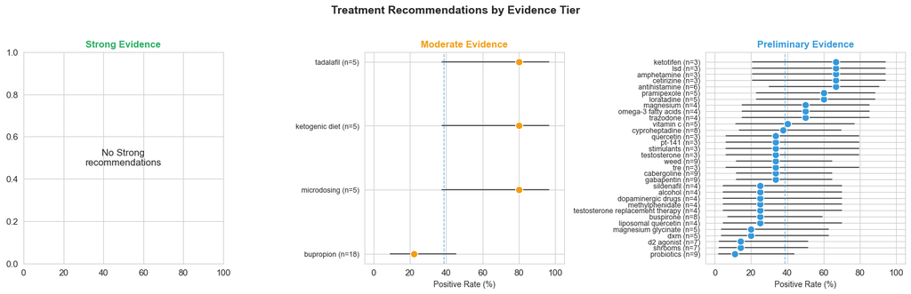

Moderate Evidence (4 treatments)

|  | Treatment | Mechanism | Users | Pos Rate | CI | p-value |
| --- | --- | --- | --- | --- | --- | --- |
| 138 | microdosing | Psychedelics | 5 | 80% | 38% to 96% | 0.0768 |
| 101 | ketogenic diet | Diet / Lifestyle | 5 | 80% | 38% to 96% | 0.0768 |
| 199 | tadalafil | PDE5 Inhibitors | 5 | 80% | 38% to 96% | 0.0768 |
| 32 | bupropion | Dopaminergic | 18 | 22% | 9% to 45% | 0.9577 |

Preliminary Evidence (32 treatments)

|  | Treatment | Mechanism | Users | Pos Rate | CI | p-value |
| --- | --- | --- | --- | --- | --- | --- |
| 19 | antihistamine | Antihistamines / Mast Cell | 6 | 67% | 30% to 90% | 0.1605 |
| 102 | ketotifen | Antihistamines / Mast Cell | 3 | 67% | 21% to 94% | 0.3321 |
| 16 | amphetamine | Dopaminergic | 3 | 67% | 21% to 94% | 0.3321 |
| 37 | cetirizine | Antihistamines / Mast Cell | 3 | 67% | 21% to 94% | 0.3321 |
| 117 | lsd | Psychedelics | 3 | 67% | 21% to 94% | 0.3321 |
| 113 | loratadine | Antihistamines / Mast Cell | 5 | 60% | 23% to 88% | 0.2937 |
| 166 | pramipexole | Dopaminergic | 5 | 60% | 23% to 88% | 0.2937 |
| 154 | omega-3 fatty acids | Supplements | 4 | 50% | 15% to 85% | 0.5006 |
| 206 | trazodone | Other Pharmaceuticals | 4 | 50% | 15% to 85% | 0.5006 |
| 119 | magnesium | Supplements | 4 | 50% | 15% to 85% | 0.5006 |
| 213 | vitamin c | Supplements | 5 | 40% | 12% to 77% | 0.6386 |
| 50 | cyproheptadine | Serotonin Antagonists | 8 | 38% | 14% to 69% | 0.6549 |
| 74 | gabapentin | Other Pharmaceuticals | 9 | 33% | 12% to 65% | 0.7411 |
| 175 | quercetin | Antihistamines / Mast Cell | 3 | 33% | 6% to 79% | 0.7686 |
| 215 | weed | Other Pharmaceuticals | 9 | 33% | 12% to 65% | 0.7411 |
| 34 | cabergoline | Dopaminergic | 9 | 33% | 12% to 65% | 0.7411 |
| 174 | pt-141 | Other Pharmaceuticals | 3 | 33% | 6% to 79% | 0.7686 |
| 207 | tre | Diet / Lifestyle | 3 | 33% | 6% to 79% | 0.7686 |
| 202 | testosterone | Hormonal | 3 | 33% | 6% to 79% | 0.7686 |
| 197 | stimulants | Dopaminergic | 3 | 33% | 6% to 79% | 0.7686 |
| 203 | testosterone replacement therapy | Hormonal | 4 | 25% | 5% to 70% | 0.8580 |
| 33 | buspirone | Serotonin Antagonists | 8 | 25% | 7% to 59% | 0.8783 |
| 111 | liposomal quercetin | Antihistamines / Mast Cell | 4 | 25% | 5% to 70% | 0.8580 |
| 191 | sildenafil | PDE5 Inhibitors | 4 | 25% | 5% to 70% | 0.8580 |
| 13 | alcohol | Other Pharmaceuticals | 4 | 25% | 5% to 70% | 0.8580 |
| 136 | methylphenidate | Dopaminergic | 4 | 25% | 5% to 70% | 0.8580 |
| 55 | dopaminergic drugs | Dopaminergic | 4 | 25% | 5% to 70% | 0.8580 |
| 120 | magnesium glycinate | Supplements | 5 | 20% | 4% to 62% | 0.9128 |
| 58 | dxm | Other Pharmaceuticals | 5 | 20% | 4% to 62% | 0.9128 |
| 51 | d2 agonist | Dopaminergic | 7 | 14% | 3% to 51% | 0.9671 |
| 190 | shrooms | Psychedelics | 7 | 14% | 3% to 51% | 0.9671 |
| 167 | probiotics | Supplements | 9 | 11% | 2% to 44% | 0.9876 |